`htmlwidgets` in effect are reusable HTML/JS/CSS components (think simple Polymer or WebComponents) I don’t recommend it, but if we wanted to use an `htmlwidget` with no R, it is fairly straightforward. Even if you decided not to do this, I think it will be helpful to clear up some of the magic internals of `htmlwidgets`.

We’ll use the simple but powerful `jsonedit` from the `listviewer` package. Its JavaScript binding is very sparse, so I hope it will be a good subject.

### Output from a `htmlwidget`

Let’s start by seeing what happens when we create our htmlwidget. The `R` code would look something like this.

```
library(listviewer)
# give it an empty list() or {} in JavaScript
jsonedit(list())
```

If we open our developer tools in Chrome, we should see something like this.

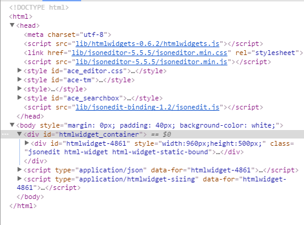

screenshot of html from htmlwidget

Each `htmlwidget` will be different, but the ingredients will usually contain:

1. JavaScript and CSS dependencies
   - `htmlwidgets.js`
   - js/css for the source libraries which are provided in the `htmlwidget` yaml

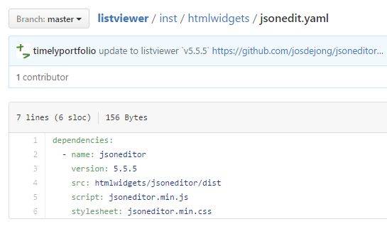

   - the htmlwidget binding - `jsonedit.js`
2. HTML tags
   - usually a `<div>` with an `id` and `class='..widgetname.. html-widget'`, but depending on the widget might be a different `tag` or set of `tags`
   - `<script type='application/json' data-for='..widgetid..'>`

### easier? way

The data `script` with `data-for` piece can be tricky to populate. Many times, it might be easier to manually render our `htmlwidget` from JavaScript.